# Perform WGCNA

```r
#setwd('/afs/inf.ed.ac.uk/user/s17/s1725186/Documents/PhD-Models/FirstPUModel/RMarkdowns')

library(tidyverse) ; library(reshape2) ; library(glue) ; library(dendextend)
library(RColorBrewer) ; require(gridExtra) ; library(GGally)
suppressMessages(library(WGCNA))
library(ClusterR)
library(expss)
```

Load preprocessed dataset (preprocessing code in 19_11_14_data_preprocessing.Rmd)

```r
# Gupta dataset
load('./../Data/preprocessed_data.RData')
datExpr = datExpr %>% data.frame
DE_info = DE_info %>% data.frame

# GO Neuronal annotations
GO_annotations = read.csv('./../../FirstYearReview/Data/GO_annotations/genes_GO_annotations.csv')
GO_neuronal = GO_annotations %>% filter(grepl('neuron', go_term)) %>%
              mutate('ID'=as.character(ensembl_gene_id)) %>%
              dplyr::select(-ensembl_gene_id) %>% distinct(ID) %>%
              mutate('Neuronal'=1)


# SFARI Genes
SFARI_genes = read_csv('./../../../PhD-Models/FirstPUModel/Data/SFARI/SFARI_genes_08-29-2019_with_ensembl_IDs.csv')
SFARI_genes = SFARI_genes[!duplicated(SFARI_genes$ID) & !is.na(SFARI_genes$ID),]


# Update DE_info with SFARI and Neuronal information
DE_info = DE_info %>% mutate('ID'=rownames(.)) %>% left_join(SFARI_genes, by='ID') %>%
  mutate(`gene-score`=ifelse(is.na(`gene-score`), 'None', `gene-score`)) %>%
  distinct(ID, .keep_all = TRUE) %>% left_join(GO_neuronal, by='ID') %>%
  mutate(Neuronal=ifelse(is.na(Neuronal), 0, Neuronal)) %>%
  mutate(gene.score=ifelse(`gene-score`=='None' & Neuronal==1, 'Neuronal', `gene-score`), significant=padj<0.05 & !is.na(padj))


# Get colors from the ggplot palette
gg_colour_hue = function(n) {
  hues = seq(15, 375, length = n+1)
  pal = hcl(h = hues, l = 65, c = 100)[1:n]
}

rm(GO_annotations)
```

# Perform Clustering

Pipeline:

- Using biweight correlation as correlation metric
- Elevating the correlation matrix to the best power for scale-free topology
- Using a Topological Overlap Matrix as distance matrix
- Performing hierarchical clustering (using average linkage hclust(method=‘average’))
- Extracting clusters using the Dynamic Tree brach cutting algorithm from [Dynamic Tree Cut: in-depth description, tests and applications](https://horvath.genetics.ucla.edu/html/CoexpressionNetwork/BranchCutting/Supplement.pdf)
- Merging similar clusters using Module Eigengenes
- Saving all results so we can decide which to use later

### Define a family of adjacency functions

- Sigmoid function: $a(i,j)=sigmoid(s_{ij}, \alpha, \tau_0) \equiv \frac{1}{1+e^{-\alpha(s_{ij}-\tau_0)}}$
- Power adjacency function: $a(i,j)=power(s_{ij}, \beta) \equiv |S_{ij}|^\beta$

Chose power adjacency function over the sigmoid function because it has only one parameter to adjust and both methods are supposed to lead to very similar results if the parameters are chosen with the scale-free topology criterion.

### Choosing a parameter value

Following the **scale-free topology criterion** because metabolic networks have been found to display approximate scale free topology

1. Only consider those parameter values that lead to a network satisfying scale-free topology at least approximately, e.g. signed $R^2 > 0.80$

**Note:** Including non-integer powers in the parameters. Integer powers are usually used for this but there’s no reason why you can’t use a non-integer power and you can get a lower power vector that is above the 0.8 threshold so you don’t affect the data that much

```r
allowWGCNAThreads()
```

```
## Allowing multi-threading with up to 4 threads.
```

```r
best_power = datExpr %>% t %>% pickSoftThreshold(powerVector = seq(1,5,0.2), RsquaredCut=0.8)
```

```
##    Power SFT.R.sq  slope truncated.R.sq mean.k. median.k. max.k.
## 1    1.0 0.012000  1.150          0.986 1830.00   1810.00 2720.0
## 2    1.2 0.000926 -0.267          0.982 1280.00   1260.00 2060.0
## 3    1.4 0.015300 -0.918          0.976  905.00    889.00 1580.0
## 4    1.6 0.034400 -1.220          0.970  650.00    635.00 1220.0
## 5    1.8 0.082900 -1.710          0.963  472.00    459.00  959.0
## 6    2.0 0.156000 -2.180          0.960  346.00    335.00  759.0
## 7    2.2 0.203000 -2.300          0.954  256.00    247.00  606.0
## 8    2.4 0.288000 -2.630          0.953  191.00    183.00  488.0
## 9    2.6 0.358000 -2.780          0.952  144.00    137.00  395.0
## 10   2.8 0.439000 -2.960          0.956  109.00    103.00  323.0
## 11   3.0 0.504000 -3.070          0.958   83.50     78.20  265.0
## 12   3.2 0.574000 -3.190          0.962   64.20     59.60  219.0
## 13   3.4 0.631000 -3.270          0.964   49.60     45.70  182.0
## 14   3.6 0.687000 -3.330          0.968   38.60     35.20  152.0
## 15   3.8 0.733000 -3.380          0.972   30.20     27.30  127.0
## 16   4.0 0.770000 -3.420          0.977   23.70     21.20  107.0
## 17   4.2 0.803000 -3.440          0.981   18.70     16.60   90.8
## 18   4.4 0.831000 -3.460          0.983   14.90     13.00   77.1
## 19   4.6 0.852000 -3.480          0.985   11.90     10.30   65.8
## 20   4.8 0.869000 -3.490          0.987    9.50      8.11   56.3
## 21   5.0 0.884000 -3.480          0.988    7.64      6.44   48.4
```

```r
cat(paste0('Best power for scale free topology: ', best_power$powerEstimate))
```

```
## Best power for scale free topology: 4.2
```

### Create Adjacency Matrix

I was originally using an unsigned (|cor|) adjacency function (because originally there were only signed and unsigned options), but there is now a third option, called signed hybrid (max(0,cor)), which Peter Langfelder recommends in his blog entry [Signed or Unsigned: which network type is preferable?](https://peterlangfelder.com/2018/11/25/signed-or-unsigned-which-network-type-is-preferable/) where he says that:

- It is important to know where node profiles go up and where they go down, and mixing negatively correlated nodes together necessarily mixes the two directions together
- Negatively correlated genes tend to come from biologically very different categories (and by using and unsigned adjacency function you are grouping themm all together)

So I switched to this one.

Using biweight midcorrelation instead of regular correlation because it’s more robust to outliers

```r
S_sft = datExpr %>% t %>% adjacency(type='signed hybrid', power=best_power$powerEstimate, corFnc='bicor')
```

```
## alpha: 1.000000
```

## Defining a measure of node dissimilarity

Using topological overlap dissimilarity measure because it has been found to result in biologically meaningful modules

```r
TOM = S_sft %>% TOMsimilarity
```

```
## ..connectivity..
## ..matrix multiplication (system BLAS)..
## ..normalization..
## ..done.
```

```r
dissTOM = 1-TOM

rownames(dissTOM) = rownames(S_sft)
colnames(dissTOM) = colnames(S_sft)

rm(S_sft, TOM)
```

## Identifying gene modules

Using hierarchical clustering using average linkage on the TOM-based dissimilarity matrix

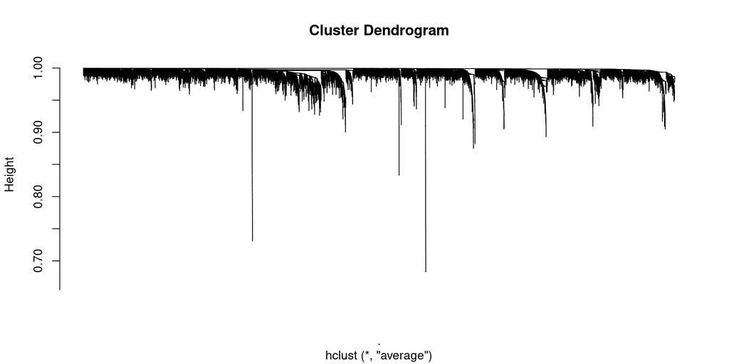

```r
dend = dissTOM %>% as.dist %>% hclust(method='average')
plot(dend, hang=0, labels=FALSE)
```

Instead of using a fixed height to cut the dendrogram into clusters, using a dynamic branch cutting approach taken from [Dynamic Tree Cut: in-depth description, tests and applications](https://horvath.genetics.ucla.edu/html/CoexpressionNetwork/BranchCutting/Supplement.pdf)

**Dynamic Tree Cut:** top-down algorithm relying only on the dendrogram and respecting the order of the clustered objects on it. This method is less sensitive to parameter choice but also less flexible and it performed better in our previous experiments **but** when using it on this dataset it left most genes without a cluster, so tried doing it also with the Dynamic Hybrid algorithm

**Dynamic Hybrid Cut:** builds the clusters from bottom up. In addition to information from the dendrogram, it utilizes dissimilarity information among the objects. Seems to me that relies on too many heuristics and has too many parameters to tune. Ran it with the default settings

### Dynamic Tree Cut Algorithm

**MOST** of genes (83%) are left without a cluster! (With Gandal’s dataset it was less than half and it was still bad)

```r
modules = cutreeDynamic(dend, method = 'tree', minClusterSize = 10)

table(modules)
```

```
## modules
##     0     1     2     3     4     5     6     7     8     9    10    11
## 12639   196   128    88    83    77    65    64    61    53    52    50
##    12    13    14    15    16    17    18    19    20    21    22    23
##    48    47    44    44    43    39    39    39    37    35    35    33
##    24    25    26    27    28    29    30    31    32    33    34    35
##    33    32    28    28    27    27    27    26    26    24    23    22
##    36    37    38    39    40    41    42    43    44    45    46    47
##    22    22    21    21    21    21    20    20    19    18    18    18
##    48    49    50    51    52    53    54    55    56    57    58    59
##    18    18    17    16    16    16    16    16    16    15    15    14
##    60    61    62    63    64    65    66    67    68    69    70    71
##    14    13    13    13    13    13    13    13    12    12    11    11
##    72    73    74    75    76    77    78    79    80    81    82    83
##    11    11    11    11    10    10    10    10    10    10    10    10
##    84
##    10
```

```r
# Note: The modules are ordered as in the rows in datExpr
```

#### Merging similar modules

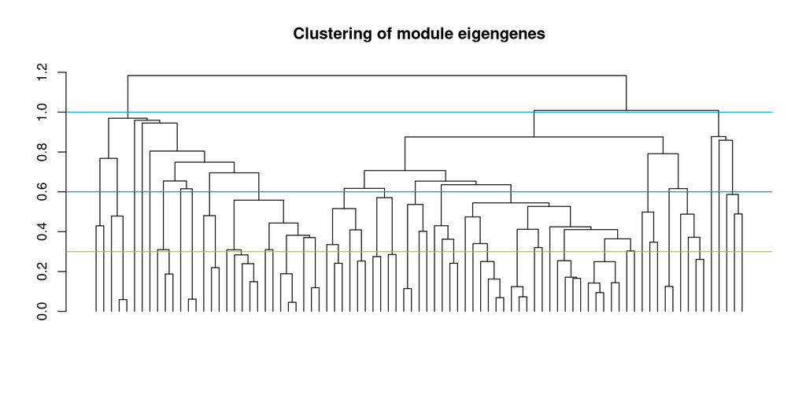

```r
# Calculate eigengenes
MEList = datExpr %>% t %>% moduleEigengenes(colors = modules)
MEs = MEList$eigengenes

# Calculate dissimilarity of module eigengenes
MEDiss = 1-cor(MEs)

# Cluster module eigengenes
METree = hclust(as.dist(MEDiss), method = 'average')

METree %>% as.dendrogram %>% plot(main = 'Clustering of module eigengenes', leaflab = 'none')
abline(h=1, col='#0099cc')
abline(h=0.6, col='#009999')
abline(h=0.3, col='#99cc00')
```

```r
merge_top = datExpr %>% t %>% mergeCloseModules(modules, cutHeight = 1)
```

```
##  mergeCloseModules: Merging modules whose distance is less than 1
##    Calculating new MEs...
```

```r
merge_similar = datExpr %>% t %>% mergeCloseModules(modules, cutHeight = 0.6)
```

```
##  mergeCloseModules: Merging modules whose distance is less than 0.6
##    Calculating new MEs...
```

```r
merge_most_similar = datExpr %>% t %>% mergeCloseModules(modules, cutHeight = 0.3)
```

```
##  mergeCloseModules: Merging modules whose distance is less than 0.3
##    Calculating new MEs...
```

```r
rm(MEList, MEs, MEDiss, METree)
```

Only the genes farthest away from the root of the tree are assigned a module. This is not very useful

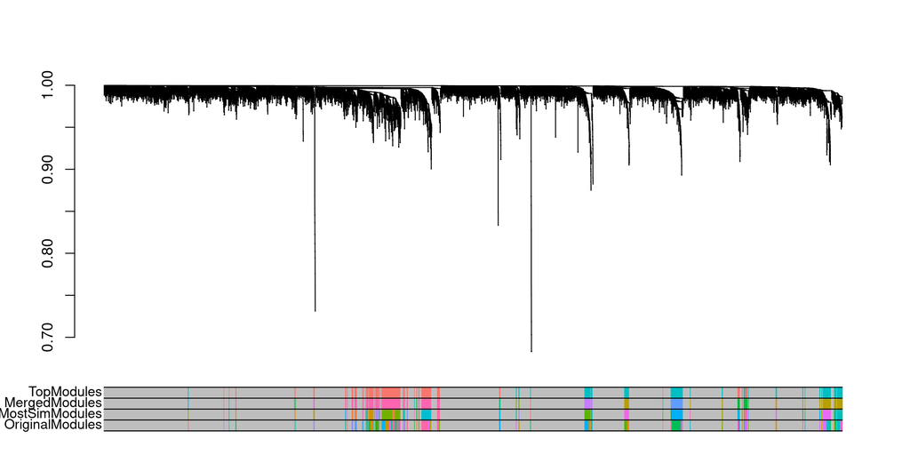

```r
get_mod_colours = function(mods){

  n = length(unique(mods))-1
  set.seed(123) ; rand_order = sample(1:n)
  mod_colors = c('gray',gg_colour_hue(n)[rand_order])
  names(mod_colors) = mods %>% table %>% names

  return(mod_colors)
}

module_colors = get_mod_colours(modules)
merged_sim_module_colors = get_mod_colours(merge_most_similar$colors)
merged_module_colors = get_mod_colours(merge_similar$colors)
top_module_colors = get_mod_colours(merge_top$colors)

dend_colors = data.frame('ID' = rownames(datExpr),
                         'OriginalModules' = module_colors[as.character(modules)],
                         'MostSimModules' = merged_sim_module_colors[as.character(merge_most_similar$colors)],
                         'MergedModules' = merged_module_colors[as.character(merge_similar$colors)],
                         'TopModules' = top_module_colors[as.character(merge_top$colors)])

dend %>% as.dendrogram(hang=0) %>% plot(ylim=c(min(dend$height),1), leaflab='none')
colored_bars(colors=dend_colors[dend$order,-1])
```

```r
rm(module_colors, merged_sim_module_colors, merged_module_colors, top_module_colors)
```

```r
modules_dynamic_tree = dend_colors

rm(dend_colors)
```

### Dynamic Hybrid Cut Algorithm

```r
modules = cutreeDynamic(dend, minClusterSize = 10, distM = dissTOM)
```

```
##  ..cutHeight not given, setting it to 0.999  ===>  99% of the (truncated) height range in dendro.
##  ..done.
```

```r
table(modules)
```

```
## modules
##   0   1   2   3   4   5   6   7   8   9  10  11  12  13  14  15  16  17
## 520 677 621 363 363 319 312 308 303 302 281 280 275 274 270 268 247 244
##  18  19  20  21  22  23  24  25  26  27  28  29  30  31  32  33  34  35
## 228 226 216 201 190 187 183 181 180 177 157 156 149 147 146 140 138 137
##  36  37  38  39  40  41  42  43  44  45  46  47  48  49  50  51  52  53
## 136 136 135 130 129 127 117 116 114 113 111 108 106 104  97  92  92  90
##  54  55  56  57  58  59  60  61  62  63  64  65  66  67  68  69  70  71
##  90  89  88  87  87  85  85  84  84  83  83  83  82  80  78  77  74  71
##  72  73  74  75  76  77  78  79  80  81  82  83  84  85  86  87  88  89
##  70  70  67  65  65  65  61  61  61  60  57  57  55  54  53  51  51  49
##  90  91  92  93  94  95  96  97  98  99 100 101 102 103 104 105 106 107
##  48  47  45  44  44  44  44  38  38  37  36  36  35  34  33  33  33  33
## 108 109 110 111 112 113 114 115 116 117 118 119 120 121 122 123
##  32  31  31  30  29  29  28  27  27  26  25  20  18  17  15  13
```

#### Merging similar modules

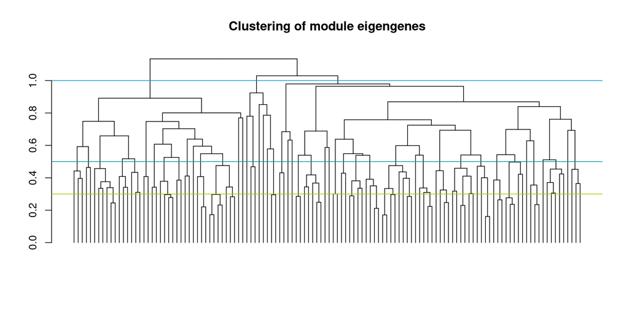

```r
# Calculate eigengenes
MEList = datExpr %>% t %>% moduleEigengenes(colors = modules)
MEs = MEList$eigengenes

# Calculate dissimilarity of module eigengenes
MEDiss = 1-cor(MEs)

# Cluster module eigengenes
METree = hclust(as.dist(MEDiss), method = 'average')

METree %>% as.dendrogram %>% plot(main = 'Clustering of module eigengenes', leaflab = 'none')
abline(h=1, col='#0099cc')
abline(h=0.5, col='#009999')
abline(h=0.3, col='#99cc00')
```

```r
merge_top = datExpr %>% t %>% mergeCloseModules(modules, cutHeight = 1)
```

```
##  mergeCloseModules: Merging modules whose distance is less than 1
##    Calculating new MEs...
```

```r
merge_similar = datExpr %>% t %>% mergeCloseModules(modules, cutHeight = 0.5)
```

```
##  mergeCloseModules: Merging modules whose distance is less than 0.5
##    Calculating new MEs...
```

```r
merge_most_similar = datExpr %>% t %>% mergeCloseModules(modules, cutHeight = 0.3)
```

```
##  mergeCloseModules: Merging modules whose distance is less than 0.3
##    Calculating new MEs...
```

```r
rm(MEList, MEs, MEDiss, METree)
```

Classification is quite noisy with respect to the dendrogram, but that isn’t necessarily a bad thing, as Peter Langfelder explains in [this blog post](https://peterlangfelder.com/2018/12/30/why-wgcna-modules-dont-always-agree-with-the-dendrogram/) from [Insights from a Million Correlations](https://peterlangfelder.com/articles/)

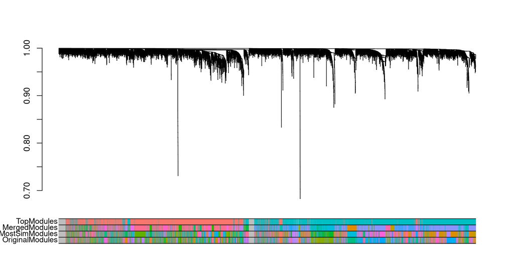

```r
module_colors = get_mod_colours(modules)
merged_sim_module_colors = get_mod_colours(merge_most_similar$colors)
merged_module_colors = get_mod_colours(merge_similar$colors)
top_module_colors = get_mod_colours(merge_top$colors)

dend_colors = data.frame('ID' = rownames(datExpr),
                         'OriginalModules' = module_colors[as.character(modules)],
                         'MostSimModules' = merged_sim_module_colors[as.character(merge_most_similar$colors)],
                         'MergedModules' = merged_module_colors[as.character(merge_similar$colors)],
                         'TopModules' = top_module_colors[as.character(merge_top$colors)])

dend %>% as.dendrogram(hang=0) %>% plot(ylim=c(min(dend$height),1), leaflab='none')
colored_bars(colors=dend_colors[dend$order,-1])
```

```r
rm(module_colors, merged_module_colors, top_module_colors)
```

```r
modules_dynamic_hybrid = dend_colors

rm(dend_colors)
```

Save clusterings file

```r
colnames(modules_dynamic_tree) = c('ID','DynamicTree', 'DynamicTreeMergedSmall', 'DynamicTreeMerged', 'DynamicTreeTop')
colnames(modules_dynamic_hybrid) = c('ID','DynamicHybrid', 'DynamicHybridMergedSmall', 'DynamicHybridMerged', 'DynamicHybridTop')

modules = modules_dynamic_tree %>% left_join(modules_dynamic_hybrid, by='ID')

write.csv(modules, file='./../Data/clusters.csv', row.names=FALSE)
```